# I - Introduction to ideas of Inference

```r
# Load packages
library(ggplot2)
library(tidyverse)
library(infer)

# Load datasets
library(NHANES) # install.packages("NHANES")
```

- Hypotheses (1) Suppose a pharmaceutical company is trying to get FDA approval for a new diabetes treatment called drug A. Currently, most doctors prescribe drug B to treat diabetes.

- Hypotheses (2) Consider the same situation as in the last exercise. A pharmaceutical company is trying to pass drug A for diabetes through the FDA, but most doctors currently prescribe drug B.

Which would be a good alternative hypothesis?: - Drug A is better than drug B at treating diabetes.

# Randomized distributions

We can build a distribution of differences in proportions assuming the null hypothesis, that there is no link between location and soda preference, is true. That is, the null samples consist of randomly shuffled soda variables so that the samples don’t have any dependency between location and soda preference.

-> Generating a distribution of the statistics from the null population gives information about whether the observed data are inconsistent with the null hypothesis.

# Working with the NHANES data

```r
colnames(NHANES)
```

```
 [1] "ID"               "SurveyYr"         "Gender"           "Age"              "AgeDecade"        "AgeMonths"        "Race1"            "Race3"
 [9] "Education"        "MaritalStatus"    "HHIncome"         "HHIncomeMid"      "Poverty"          "HomeRooms"        "HomeOwn"          "Work"
[17] "Weight"           "Length"           "HeadCirc"         "Height"           "BMI"              "BMICatUnder20yrs" "BMI_WHO"          "Pulse"
[25] "BPSysAve"         "BPDiaAve"         "BPSys1"           "BPDia1"           "BPSys2"           "BPDia2"           "BPSys3"           "BPDia3"
[33] "Testosterone"     "DirectChol"       "TotChol"          "UrineVol1"        "UrineFlow1"       "UrineVol2"        "UrineFlow2"       "Diabetes"
[41] "DiabetesAge"      "HealthGen"        "DaysPhysHlthBad"  "DaysMentHlthBad"  "LittleInterest"   "Depressed"        "nPregnancies"     "nBabies"
[49] "Age1stBaby"       "SleepHrsNight"    "SleepTrouble"     "PhysActive"       "PhysActiveDays"   "TVHrsDay"         "CompHrsDay"       "TVHrsDayChild"
[57] "CompHrsDayChild"  "Alcohol12PlusYr"  "AlcoholDay"       "AlcoholYear"      "SmokeNow"         "Smoke100"         "Smoke100n"        "SmokeAge"
[65] "Marijuana"        "AgeFirstMarij"    "RegularMarij"     "AgeRegMarij"      "HardDrugs"        "SexEver"          "SexAge"           "SexNumPartnLife"
[73] "SexNumPartYear"   "SameSex"          "SexOrientation"   "PregnantNow"
```

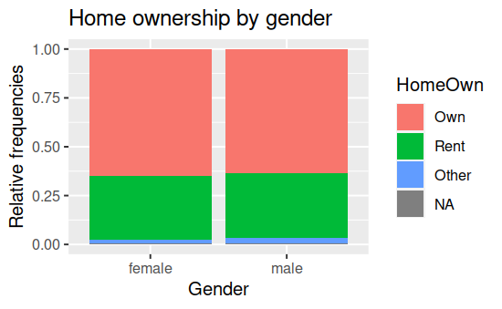

```r
# Create bar plot for Home Ownership by Gender
ggplot(NHANES, aes(x = Gender, fill = HomeOwn)) +
  # Set the position to fill
  geom_bar(position = "fill") +
  ylab("Relative frequencies") +
  ggtitle("Home ownership by gender")
```

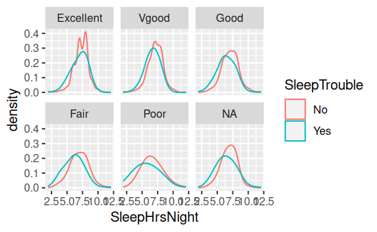

```r
ggplot(NHANES, aes(x = SleepHrsNight, color = SleepTrouble)) +
  geom_density(adjust = 2) +
  facet_wrap(~ HealthGen)
```

## Caculating statistic of interest

As seen in the video, natural variability can be modeled from shuffling observations around to remove any relationships that might exist in the population. However, before you permute the data, you need to calculate the original observed statistic. In this exercise, you will calculate the difference in proportion of home owners who are men versus women.

```r
homes <- NHANES %>%
  select(Gender, HomeOwn) %>%
  filter(HomeOwn %in% c("Own", "Rent"))
homes
```

| Gender | HomeOwn |
| --- | --- |
| male | Own |
| male | Own |
| male | Own |
| male | Own |
| female | Rent |
| male | Rent |
| male | Own |
| female | Own |
| female | Own |
| female | Own |

[output cut: 990 more lines]

Calculating difference in ownership between genders.

```r
diff_orig <- homes %>%
  group_by(Gender) %>%
  summarize(prop_own = mean(HomeOwn == "Own")) %>%
  summarize(obs_diff_prop = diff(prop_own)) # male - female

diff_orig
```

| obs_diff_prop |
| --- |
| -0.007828723 |

## Randomized data under the null model of independence

The infer package will allow you to model a particular null hypothesis and then randomize the data to calculate permuted statistics. In this exercise, after specifying your null hypothesis you will permute the home ownership variable 10 times. By doing so, you will ensure that there is no relationship between home ownership and gender, so any difference in home ownership proportion for female versus male will be due only to natural variability.

```r
homeown_perm <- homes %>%
  specify(HomeOwn ~ Gender, success = "Own") %>%
  hypothesize(null = "independence") %>%
  generate(reps = 10, type = "permute")
```

```
Dropping unused factor levels Other from the supplied response variable 'HomeOwn'.
```

```r
homeown_perm
```

```
Response: HomeOwn (factor)
Explanatory: Gender (factor)
Null Hypothesis: independence
```

| HomeOwn | Gender | replicate |
| --- | --- | --- |
| Rent | male | 1 |
| Rent | male | 1 |
| Own | male | 1 |
| Rent | male | 1 |
| Own | female | 1 |
| Own | male | 1 |
| Own | male | 1 |
| Rent | female | 1 |
| Own | female | 1 |
| Rent | female | 1 |

[output cut: 990 more lines]

## Randomized statistics and dotplot

By permuting the home ownership variable multiple times, you generate differences in proportions that are consistent with the assumption that the variables are unrelated. The statistic of interest is the difference in proportions given by stat = “diff in props”. After calculating the randomized statistics, you will plot them in a dotplot.

```r
# Perform 100 permutations
homeown_perm <- homes %>%
  specify(HomeOwn ~ Gender, success = "Own") %>%
  hypothesize(null = "independence") %>%
  generate(reps = 100, type = "permute") %>%
  calculate(stat = "diff in props", order = c("male", "female"))
```

```
Dropping unused factor levels Other from the supplied response variable 'HomeOwn'.
```

```r
homeown_perm
```

```
Response: HomeOwn (factor)
Explanatory: Gender (factor)
Null Hypothesis: independence
```

| replicate | stat |
| --- | --- |
| 1 | 0.0024683222 |
| 2 | 0.0069990220 |
| 3 | -0.0177138863 |
| 4 | 0.0119416037 |
| 5 | -0.0074168412 |
| 6 | -0.0008267323 |
| 7 | 0.0098821947 |
| 8 | 0.0140010127 |
| 9 | -0.0061811958 |
| 10 | 0.0037039676 |

[output cut: 90 more lines]

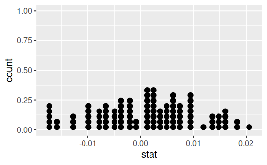

```r
# Dotplot of 100 permuted differences in proportions
ggplot(homeown_perm, aes(x = stat)) +
  geom_dotplot(binwidth = 0.001)
```

## Randomization density

Using 100 repetitions allows you to understand the mechanism of permuting. However, 100 is not enough to observe the full range of likely values for the null differences in proportions. In this exercise, you’ll repeat the process 1000 times to get a sense for the complete distribution of null differences in proportions.

```r
# Perform 1000 permutations
  # Specify HomeOwn vs. Gender, with `"Own" as success
homeown_perm <- homes %>%
  specify(HomeOwn ~ Gender, success = "Own") %>%# Density plot of 1000 permuted differences in proportions

  hypothesize(null = "independence") %>%
  generate(reps = 1000, type = "permute") %>%
  calculate(stat = "diff in props", order = c("male", "female"))
```

```
Dropping unused factor levels Other from the supplied response variable 'HomeOwn'.
```

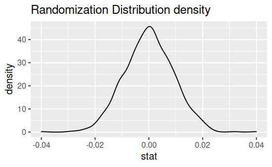

```r
# Density plot of 1000 permuted differences in proportions
ggplot(homeown_perm, aes(x = stat)) +
  geom_density() +
  ggtitle("Randomization Distribution density")
```

# Using the randomization distribution

## Do the data come from the population ?

```r
homeown_perm
```

```
Response: HomeOwn (factor)
Explanatory: Gender (factor)
Null Hypothesis: independence
```

| replicate | stat |
| --- | --- |
| 1 | 4.527731e-03 |
| 2 | 4.115849e-03 |
| 3 | 2.468322e-03 |
| 4 | -9.888132e-03 |
| 5 | -2.062378e-03 |
| 6 | -1.936141e-02 |
| 7 | -5.357432e-03 |
| 8 | -4.121787e-03 |
| 9 | 1.644559e-03 |
| 10 | 6.587140e-03 |

[output cut: 990 more lines]

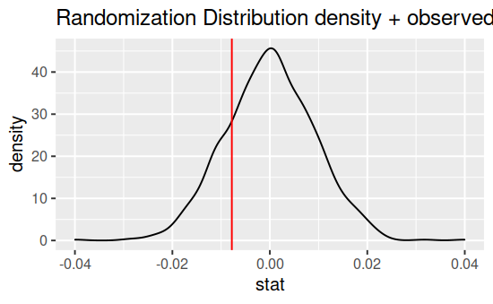

```r
diff_orig = -0.0078

# Plot permuted differences, diff_perm
ggplot(homeown_perm, aes(x = stat)) +
  geom_density() +
  geom_vline(aes(xintercept = diff_orig), color = "red") +
  ggtitle("Randomization Distribution density + observed sample" )
```

```r
homeown_perm %>%
  summarize(n_perm_le_obs = sum(diff_perm <= diff_orig)) #212
```

[output not shown]

In other words: **We fail to reject the null hypothesis** -> There is no evidence that our dat are inconsistent with the null hypothesis.

This code throws and error because the homeown_perm from datacamp is modified without further explanations:

```r
# A tibble: 1,000 x 3
#   replicate diff_perm diff_orig
#       <int>     <dbl>     <dbl>
# 1         1  -0.00289  -0.00783
# 2         2  -0.00289  -0.00783
# 3         3   0.00659  -0.00783
# 4         4   0.00412  -0.00783
# 5         5   0.00494  -0.00783
# 6         6   0.00453  -0.00783
# 7         7  -0.0111   -0.00783
# 8         8  -0.0185   -0.00783
# 9         9  -0.00206  -0.00783
#10        10  -0.0115   -0.00783
# ... with 990 more rows
```

Its possible to be calculated with the calculate(stat = “diff in props”, …)